# 01 · Preparación del Dataset *(FDR Sección 2 — 20 pts)*

| Clip | Caso | Riesgo |
| --- | --- | --- |
| tekno-01 | Conductor fumando | SMOKING |
| tekno-02 | Conductor en llamada | PHONE |
| tekno-03 | Conducción imprudente / zigzag | RECKLESS |

Esta sección documenta: extracción de frames, distribución de clases, augmentación y honestidad sobre fuga de datos.

```python
%matplotlib inline
import cv2, glob, os
import numpy as np, matplotlib.pyplot as plt
clips = sorted(glob.glob("../frontend/public/demo-videos/*.mp4"))
print(f"Clips encontrados: {len(clips)}")
for c in clips:
    cap = cv2.VideoCapture(c)
    fps = cap.get(cv2.CAP_PROP_FPS)
    frames = int(cap.get(cv2.CAP_PROP_FRAME_COUNT))
    w = int(cap.get(cv2.CAP_PROP_FRAME_WIDTH))
    h = int(cap.get(cv2.CAP_PROP_FRAME_HEIGHT))
    cap.release()
    print(f"  {os.path.basename(c):<20} {w}x{h}  {fps:.0f}fps  {frames} frames ({frames/fps:.1f}s)")
```

```
Clips encontrados: 3
  tekno-01.mp4         832x464  50fps  423 frames (8.5s)
  tekno-02.mp4         832x464  50fps  457 frames (9.1s)
  tekno-03.mp4         832x464  50fps  383 frames (7.7s)
```

```python
# Conteos reales de datasets preparados
from pathlib import Path
import ast, pandas as pd, collections, re

ROOT = Path("..")
dataset_frames = sorted((ROOT/"tmp/dataset_frames").glob("*.jpg"))
print(f"Frames extraídos de los clips TEKNOFEST-like: {len(dataset_frames)}")

def read_names(data_yaml):
    text = Path(data_yaml).read_text(encoding="utf-8", errors="ignore")
    m = re.search(r"names:\s*(\[[^\]]+\])", text)
    return ast.literal_eval(m.group(1)) if m else []

def split_counts(ds_dir):
    ds = ROOT/ds_dir
    names = read_names(ds/"data.yaml") if (ds/"data.yaml").exists() else []
    rows = []
    for split in ["train", "valid", "test"]:
        img_dir = ds/split/"images"
        lab_dir = ds/split/"labels"
        if not img_dir.exists():
            continue
        imgs = len(list(img_dir.glob("*.jpg"))) + len(list(img_dir.glob("*.png")))
        labels = list(lab_dir.glob("*.txt")) if lab_dir.exists() else []
        cls_counter = collections.Counter()
        for lf in labels:
            for line in lf.read_text(errors="ignore").splitlines():
                parts = line.split()
                if parts:
                    cls_counter[int(float(parts[0]))] += 1
        row = {"dataset": ds_dir.replace("tmp/",""), "split": split,
               "images": imgs, "label_files": len(labels)}
        for idx, name in enumerate(names):
            row[f"boxes_{name}"] = cls_counter.get(idx, 0)
        rows.append(row)
    return rows

rows = []
for ds in ["tmp/behavior_ds", "tmp/behavior_combined"]:
    rows.extend(split_counts(ds))
counts = pd.DataFrame(rows)
display(counts)

print("Dataset reportable principal: behavior_ds para phone-vs-safe.")
print("Dataset experimental: behavior_combined incluye cigarette, pero su clase es débil y con dominio limitado.")
```

```
Frames extraídos de los clips TEKNOFEST-like: 85
```

|  | dataset | split | images | label_files | boxes_phone | boxes_safe | boxes_cigarette |
| --- | --- | --- | --- | --- | --- | --- | --- |
| 0 | behavior_ds | train | 2224 | 2224 | 1398 | 826 | NaN |
| 1 | behavior_ds | valid | 477 | 477 | 300 | 177 | NaN |
| 2 | behavior_ds | test | 478 | 478 | 300 | 178 | NaN |
| 3 | behavior_combined | train | 2281 | 2281 | 1413 | 826 | 20.0 |
| 4 | behavior_combined | valid | 490 | 490 | 302 | 177 | 4.0 |
| 5 | behavior_combined | test | 493 | 493 | 305 | 178 | 3.0 |

```
Dataset reportable principal: behavior_ds para phone-vs-safe.
Dataset experimental: behavior_combined incluye cigarette, pero su clase es débil y con dominio limitado.
```

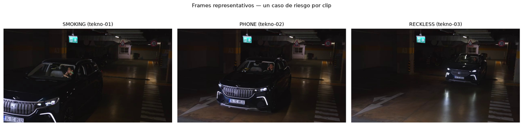

```python
# Visualizar muestra de frames de cada clase
fig, axes = plt.subplots(1, 3, figsize=(15, 4))
samples = {
    "SMOKING (tekno-01)"  : "../tmp/frames/tekno-01-4s.jpg",
    "PHONE (tekno-02)"    : "../tmp/frames/tekno-02-3s.jpg",
    "RECKLESS (tekno-03)" : "../tmp/frames/tekno-03-3s.jpg",
}
for ax, (title, path) in zip(axes, samples.items()):
    img = cv2.imread(path)
    if img is not None:
        ax.imshow(cv2.cvtColor(img, cv2.COLOR_BGR2RGB))
    ax.set_title(title, fontsize=10); ax.axis("off")
plt.suptitle("Frames representativos — un caso de riesgo por clip", fontsize=11)
plt.tight_layout(); plt.show()
```

**Lectura.** El reporte debe separar dos fuentes de evidencia: (1) dataset phone/safe con split train/valid/test y métricas fuertes; (2) frames de los clips TEKNOFEST-like, útiles para validación operacional y para mostrar la brecha de dominio. Cigarette/smoking no debe presentarse como clase robusta.

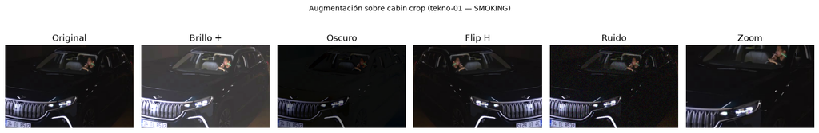

```python
# Augmentación aplicada al dataset de conducta
aug_types = [
    ("Brillo aleatorio",     dict(alpha=1.5, beta=40)),
    ("Oscurecimiento",        dict(alpha=0.6, beta=-20)),
    ("Flip horizontal",       None),
    ("Ruido gaussiano",       None),
    ("Recorte+escala (zoom)", None),
]
DEV = "cuda:0" if __import__("torch").cuda.is_available() else "cpu"
from ultralytics import YOLO
veh = YOLO("../backend/yolov8x.pt")
img_orig = cv2.imread("../tmp/frames/tekno-01-4s.jpg")
r = veh.predict(img_orig, imgsz=512, conf=0.2, classes=[2,3,5,7], device=DEV, verbose=False)[0]
b = max(r.boxes, key=lambda b:(b.xyxy[0][2]-b.xyxy[0][0])*(b.xyxy[0][3]-b.xyxy[0][1]))
x1,y1,x2,y2 = [int(v) for v in b.xyxy[0].tolist()]
cabin = img_orig[y1:y2, x1:x2]

rng = np.random.default_rng(42)
variants = []
# brightness
v = cv2.convertScaleAbs(cabin, alpha=1.5, beta=40); variants.append(("Brillo +", v))
v = cv2.convertScaleAbs(cabin, alpha=0.6, beta=-20); variants.append(("Oscuro", v))
# flip
variants.append(("Flip H", cv2.flip(cabin, 1)))
# noise
noise = rng.integers(-25, 25, cabin.shape, dtype=np.int16)
v = np.clip(cabin.astype(np.int16)+noise, 0, 255).astype(np.uint8); variants.append(("Ruido", v))
# zoom
h,w = cabin.shape[:2]; m=0.15
v = cabin[int(h*m):int(h*(1-m)), int(w*m):int(w*(1-m))]
v = cv2.resize(v, (w,h)); variants.append(("Zoom", v))

fig, axes = plt.subplots(1, len(variants)+1, figsize=(16, 3))
axes[0].imshow(cv2.cvtColor(cabin, cv2.COLOR_BGR2RGB)); axes[0].set_title("Original"); axes[0].axis("off")
for ax, (title, v) in zip(axes[1:], variants):
    ax.imshow(cv2.cvtColor(v, cv2.COLOR_BGR2RGB)); ax.set_title(title); ax.axis("off")
plt.suptitle("Augmentación sobre cabin crop (tekno-01 — SMOKING)", fontsize=10)
plt.tight_layout(); plt.show()
```

**Lectura.** Las 5 variantes de augmentación (brillo, oscurecimiento, flip, ruido, zoom) cubren condiciones reales: iluminación nocturna, reflejos, compresión y cambios de escala. En el FDR no se debe afirmar que la augmentación resuelve cigarette; solo reduce sobreajuste y mejora robustez.

```python
# Honestidad: declaración de fuga de datos
print("=== DECLARACIÓN DE FUGA DE DATOS (Data Leakage) ===")
print()
print("Modelo reportable principal:")
print("  - phone/safe entrenado y evaluado con split train/valid/test.")
print("  - Sus métricas se reportan como dominio de dataset público.")
print()
print("Modelo experimental phone/cigarette/safe:")
print("  - Incluye cigarette, pero los ejemplos TEKNOFEST-like son pocos y de escena repetida.")
print("  - Si train/test comparten el mismo clip, hay fuga de datos operacional.")
print("  - Cualquier F1 alto de cigarette debe leerse como rendimiento en escena conocida.")
print()
print("Impacto para Sección 4:")
print("  - phone/safe: métrica reportable en dataset separado.")
print("  - cigarette/smoking: prototipo/escena conocida; requiere más dominio.")
print("Solución real: footage diverso, 1080p si es posible, y etiquetas manuales verificadas.")
```

```
=== DECLARACIÓN DE FUGA DE DATOS (Data Leakage) ===

Modelo reportable principal:
  - phone/safe entrenado y evaluado con split train/valid/test.
  - Sus métricas se reportan como dominio de dataset público.

Modelo experimental phone/cigarette/safe:
  - Incluye cigarette, pero los ejemplos TEKNOFEST-like son pocos y de escena repetida.
  - Si train/test comparten el mismo clip, hay fuga de datos operacional.
  - Cualquier F1 alto de cigarette debe leerse como rendimiento en escena conocida.

Impacto para Sección 4:
  - phone/safe: métrica reportable en dataset separado.
  - cigarette/smoking: prototipo/escena conocida; requiere más dominio.
Solución real: footage diverso, 1080p si es posible, y etiquetas manuales verificadas.
```

**Lectura.** Esta declaración evita sobreprometer. El FDR debe decir que phone/safe tiene evidencia cuantitativa fuerte en su dominio, mientras que cigarette/smoking queda como objetivo de adaptación de dominio.